# Effective climate action can only be global in scope

Insights from a Core-Periphery SOCIO-ECO-MRIO-SFC Model

Author

Affiliation

Oriol Vallès Codina

Johns Hopkins University, Net Zero Industrial Policy Lab, Department of Political Science

Published

January 14, 2026

# Initialization

The initial values and variables are loaded from the file stored in variable `identif` in a different structure as before.

# Network Analysis of the MRIO $A$ Matrix

## Static Visualization

Importantly, the column names of the $A$ matrix contained in `identif` determine the country and industry labels in the whole model, following the grammar `country_label.industry_label`:

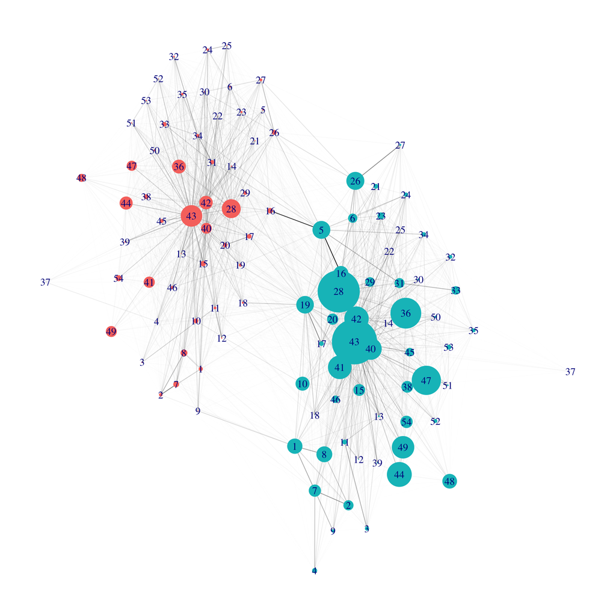

## Dynamic Visualization

[interactive chart not shown]

## Top Nodes by Size (Top Industries by Gross Output)

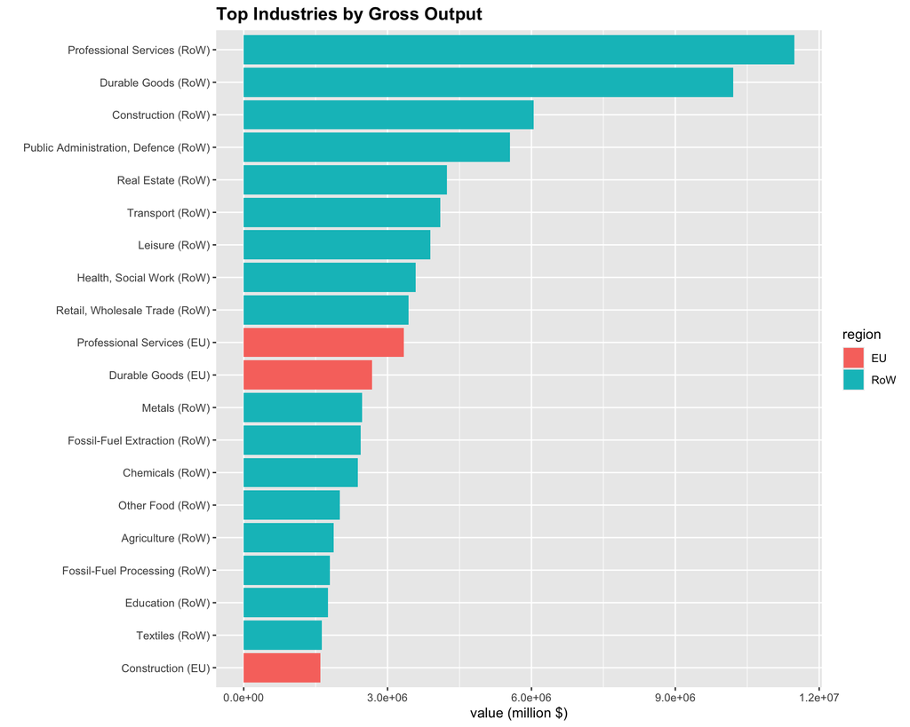

## Top Edges

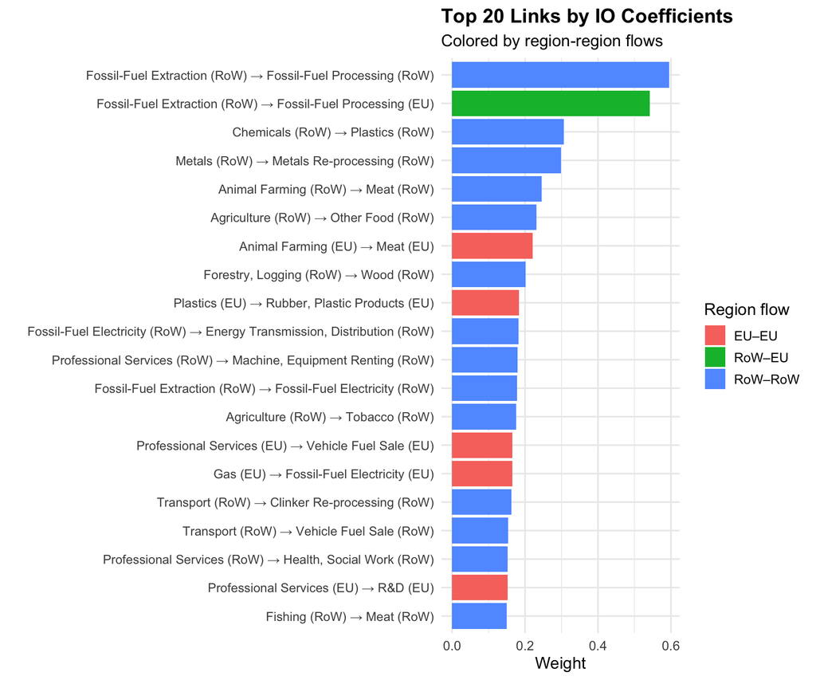

```
[1] "top20 links by region-region flow"
```

```
      EU RoW
  EU   5   0
  RoW  1  14
```

```
[1] "percentage out of all links by region-region flow"
```

```
         EU   RoW
  EU  42.57  4.65
  RoW 12.06 40.72
```

> Out of the top 20 links, 14 are RoW-RoW production links, 5 are EU-EU production links, and only 1 is a cross-border link from RoW to the EU, the second largest IO coefficient: Fossil-Fuel Extraction (RoW) to Fossil-Fuel Processing (EU).

> There are 3 times more production links from RoW to the EU than from the EU to RoW.

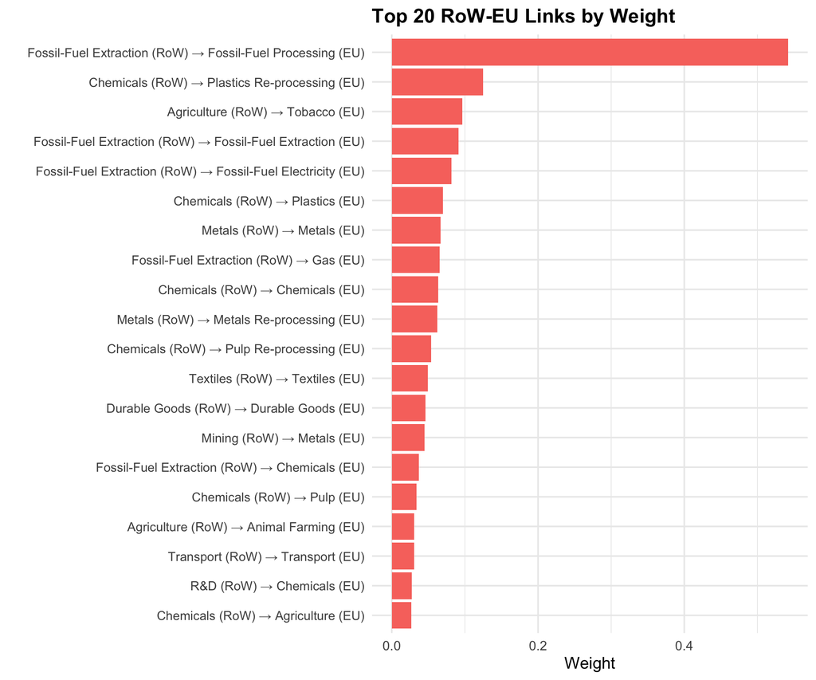

## Intensities

### Carbon Intensity

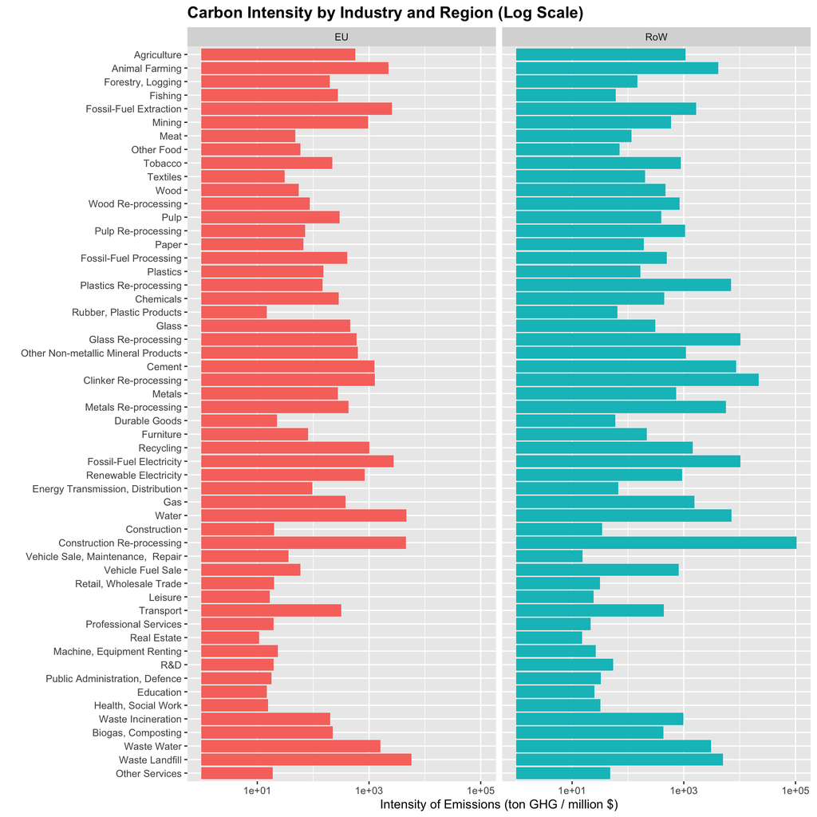

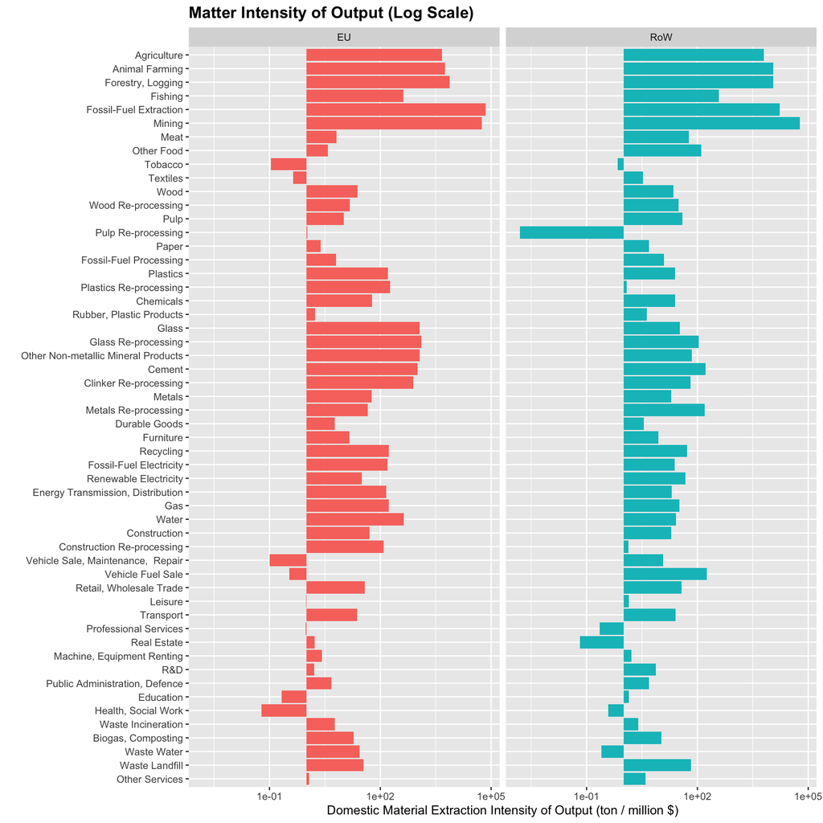

# Intensity-Output Plots

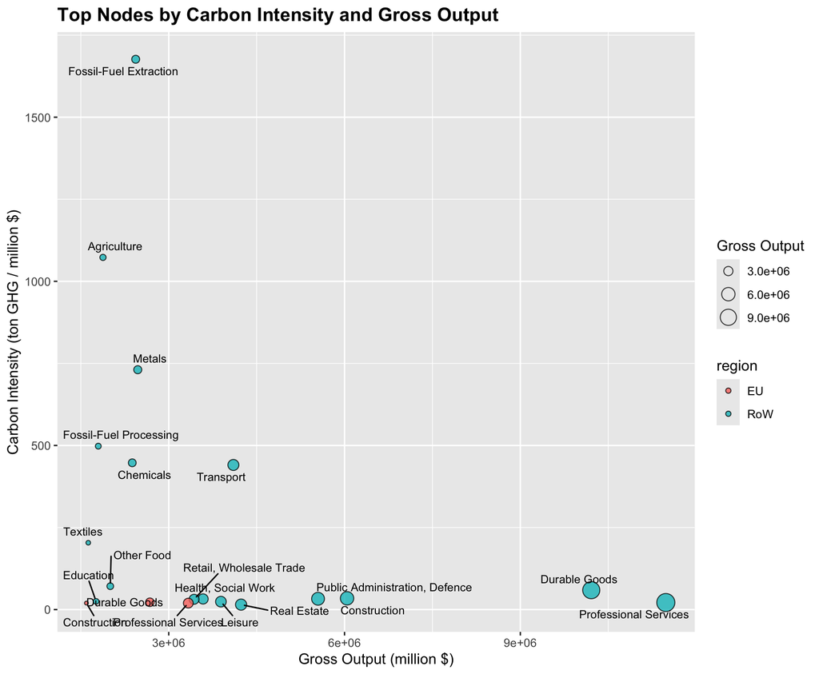

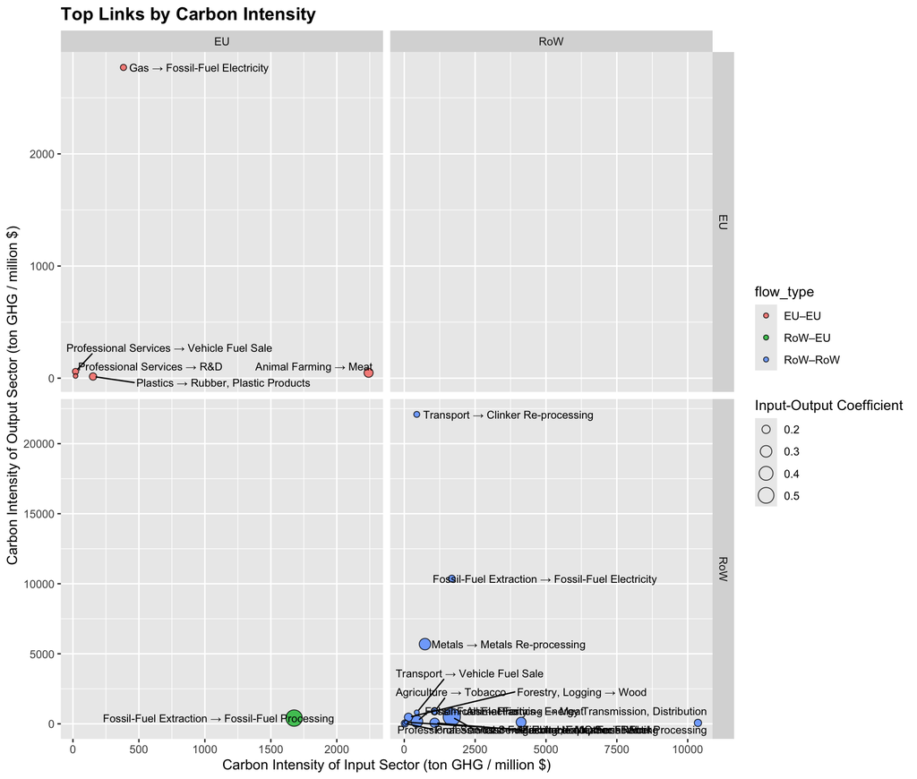

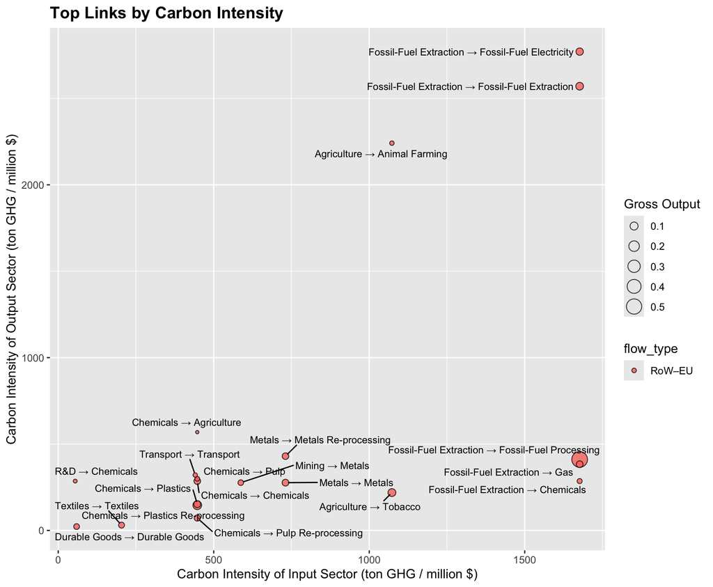

# Calibration

Target values are loaded in format long (`target.set`) and wide (`target.table.0`). Units are divided by 10,000 for convenience.

```
$table
             Z1_c        Z2_c       Z1_id      Z2_id       Z1_g        Z2_g
value  626.317880 2370.705952 196.6150852 908.672096 239.459251 675.3283891
target 639.442534 2490.186243 193.4427224 926.058386 240.000000 675.0000000
ratio    1.020955    1.050399   0.9838651   1.019134   1.002258   0.9995137
           Z1_rex     Z2_rex     Z1_imp     Z2_imp Z1_M_TOT_int Z2_M_TOT_int
value  102.775931 66.3570804 66.3570804 102.775931   123.151817   105.854567
target 103.050978 60.7293075 60.7293075 103.050978   125.474198   108.929424
ratio    1.002676  0.9151896  0.9151896   1.002676     1.018858     1.029048
             Z1_fd       Z2_fd       Z1_va       Z2_va       Z1_go       Z2_go
value  1098.811066 3918.287587 1081.513816 3935.584836 2153.602494 8424.517003
target 1165.206927 4278.922959 1237.843213 4580.169886 2188.158529 8687.182370
ratio     1.060425    1.092039    1.144547    1.163784    1.016046    1.031179
           Z1_gdef    Z2_gdef Z1_debt_gdp Z2_debt_gdp      Z1_b_s      Z2_b_s
value   0.25000000  0.2500000    0.800000    0.600000 1373.000000 5040.000000
target -0.02477849 -0.1872231    1.109977    1.101777 1373.977228 5046.325726
ratio  -0.09911398 -0.7488925    1.387471    1.836295    1.000712    1.001255

$total.fit
[1] 0.2165201

$fitness
[1] 0.2165201
```

# Shock Example 7: Product Lifetime Extension

## Run Shock

This is a simple visualization of shock 7. Please note the new grammar to change initial values.

## Visualize Shocked Variables

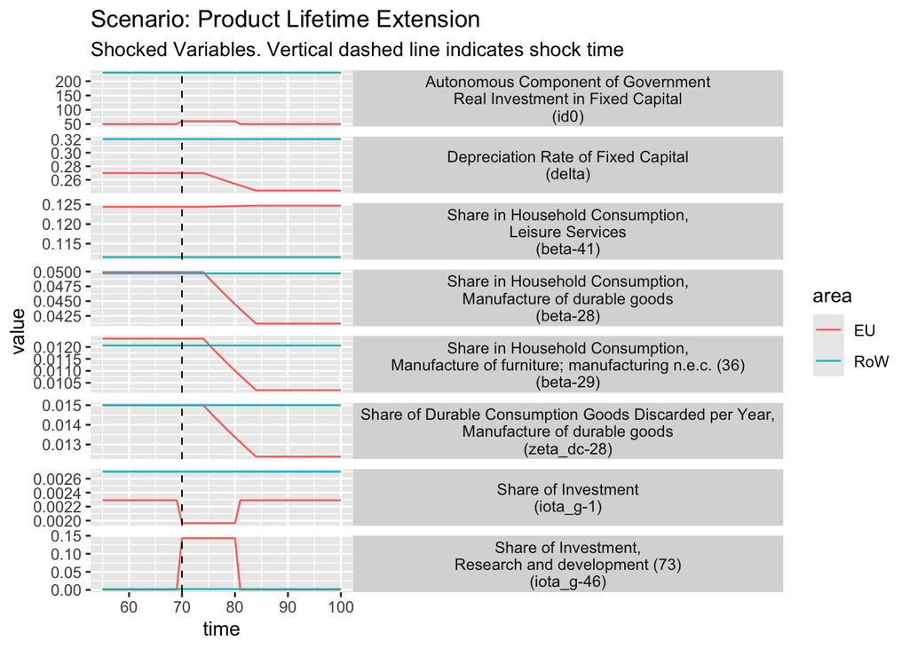

## Visualize Impacts

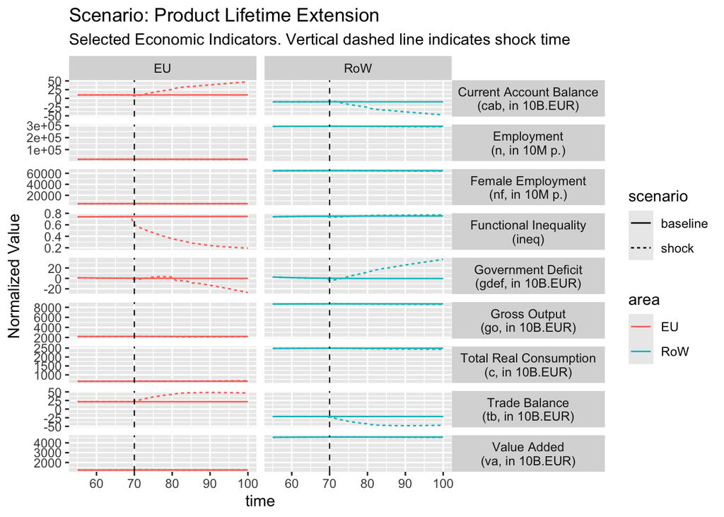

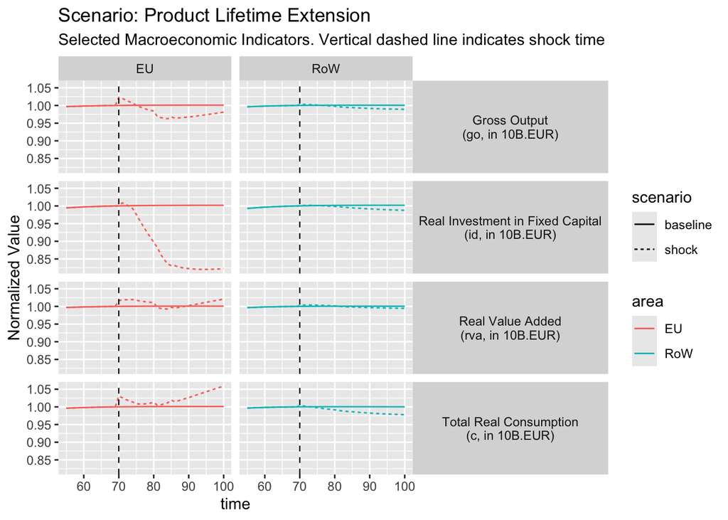

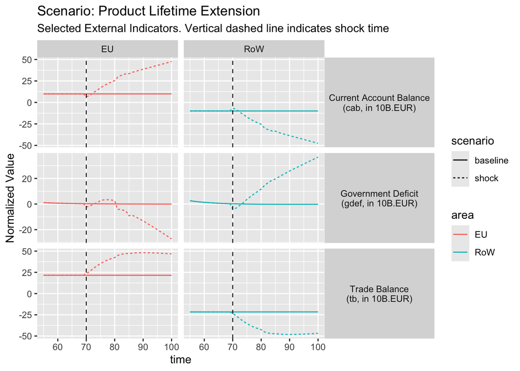

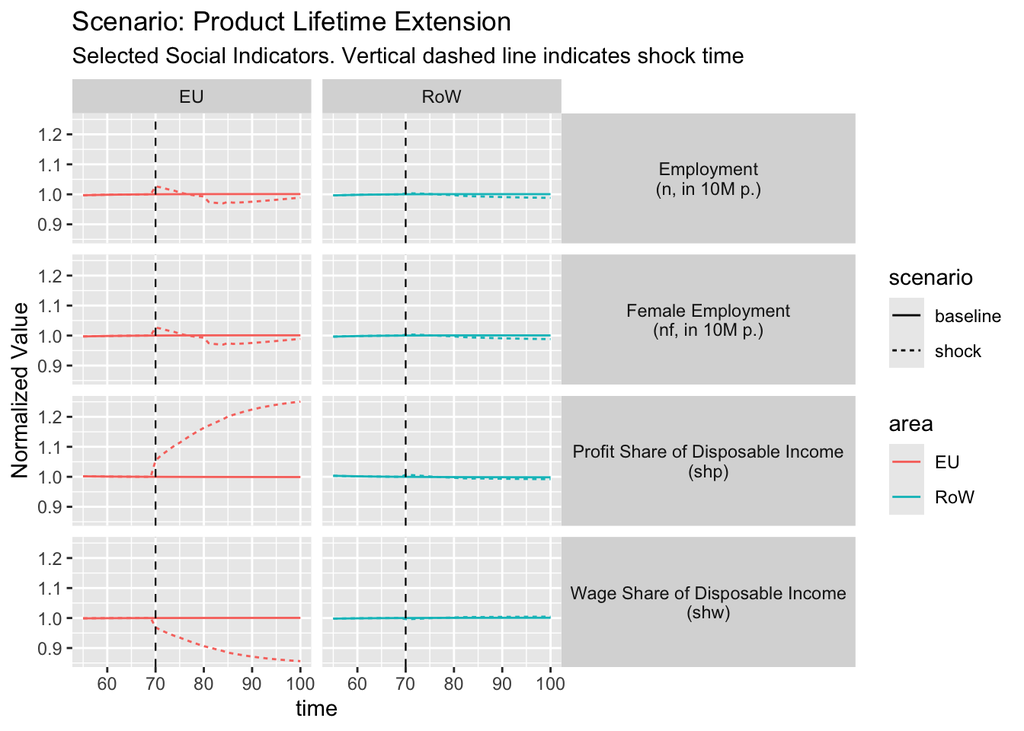

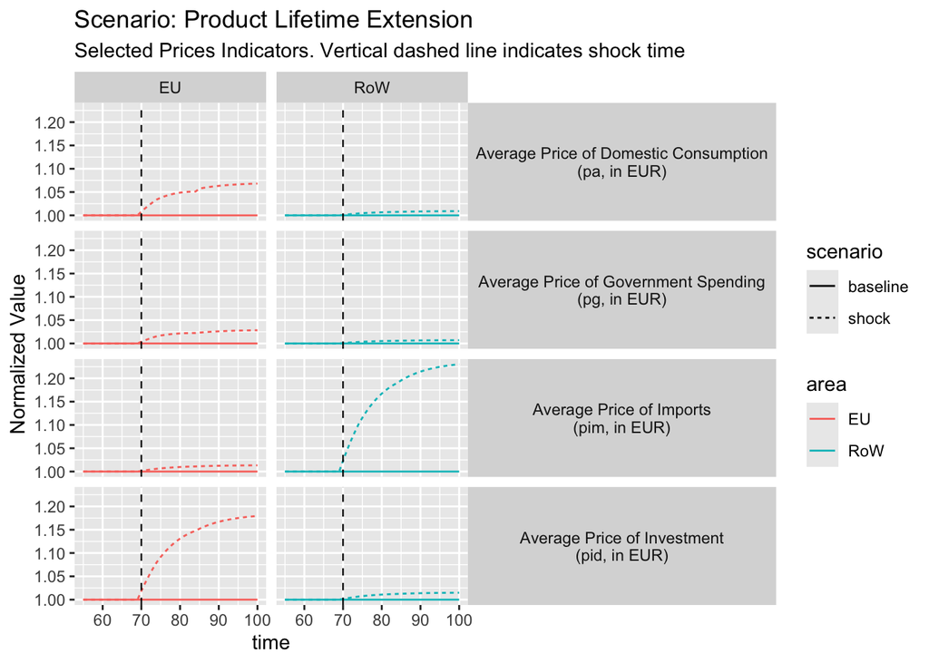

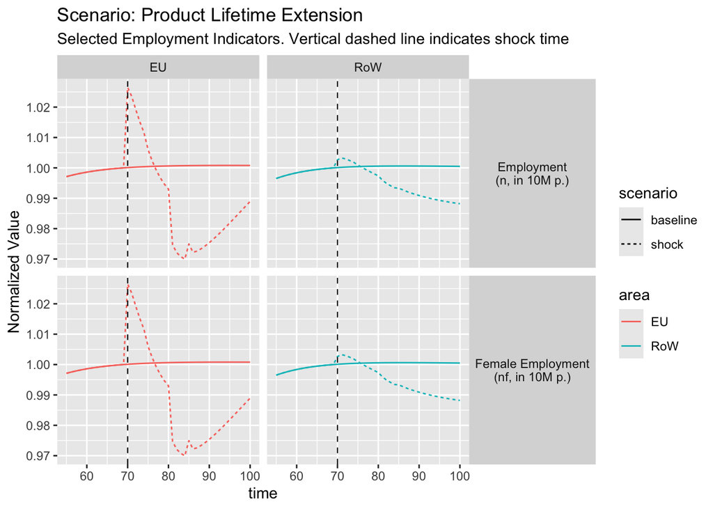

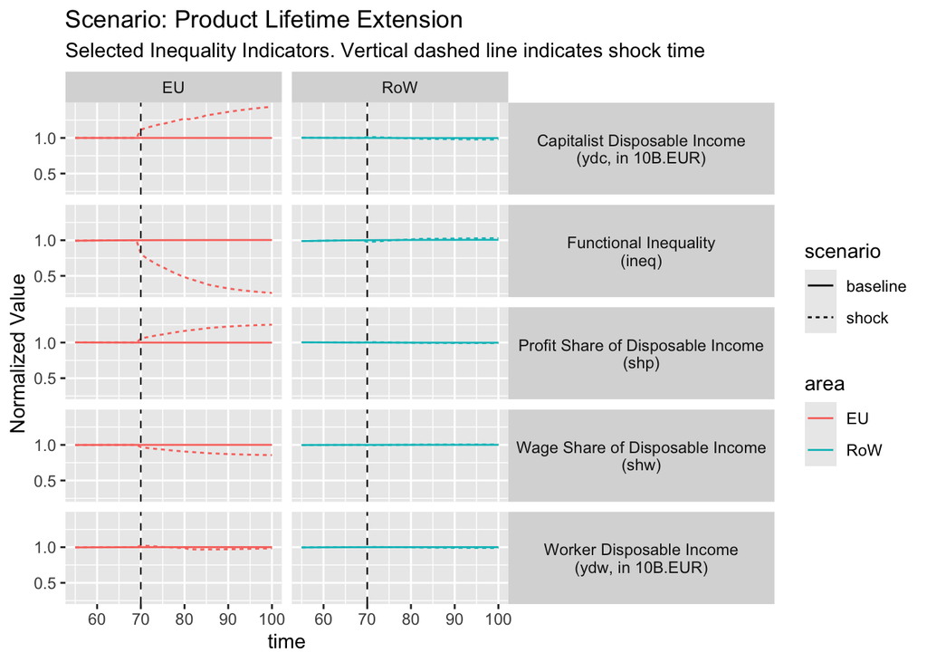

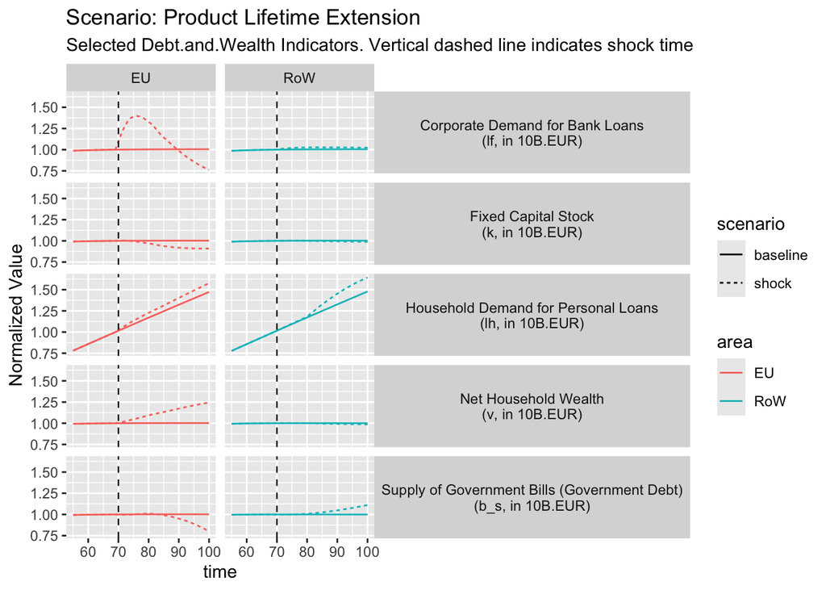

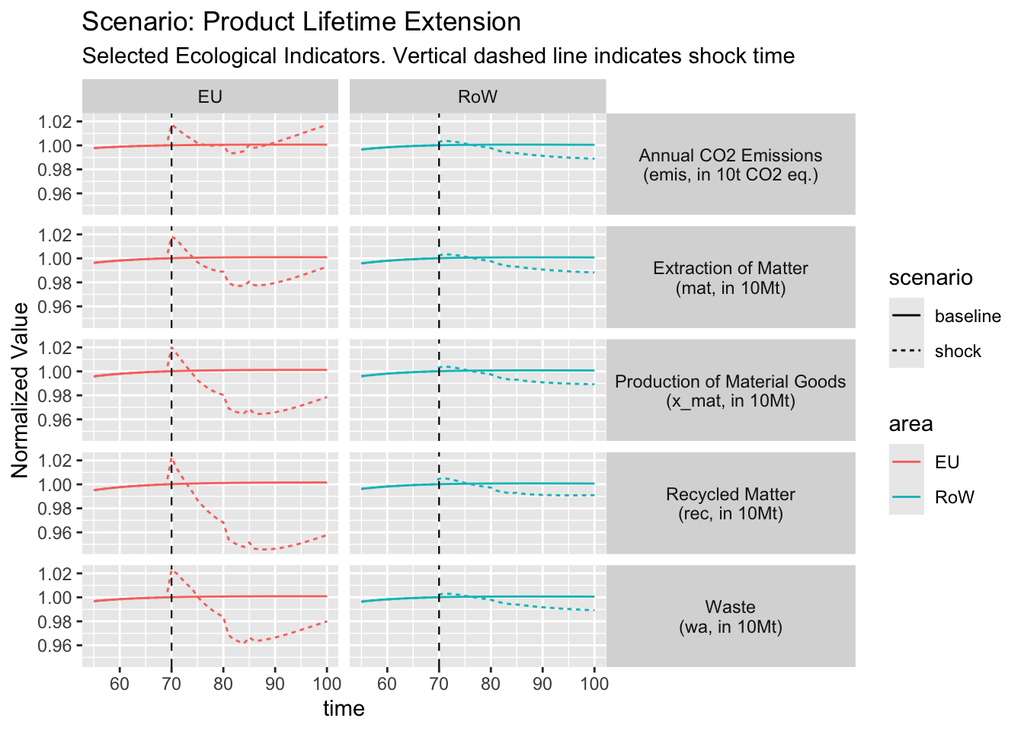

## Visualize Selected Variables Without Function

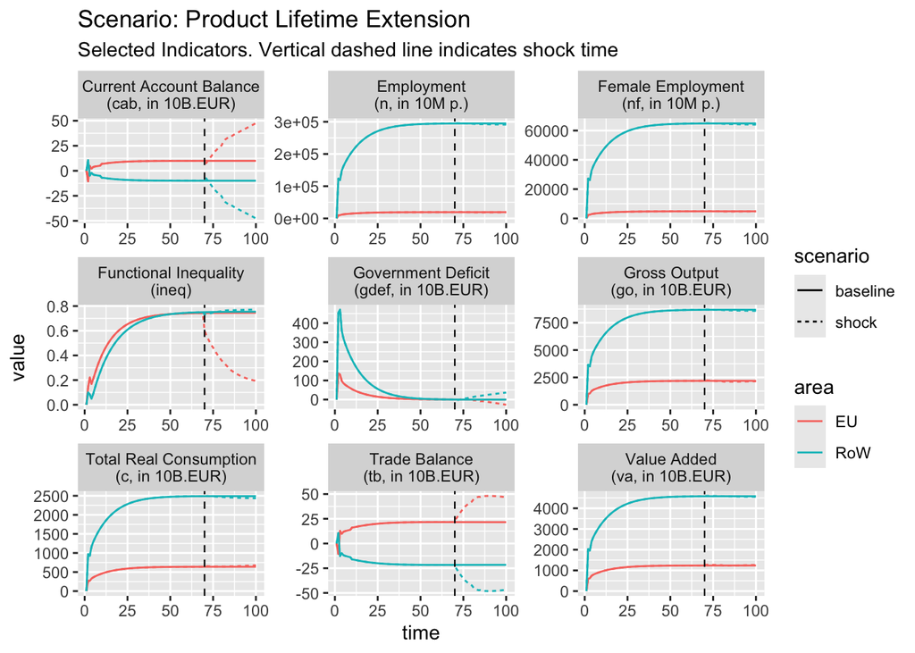

## Summary Table

| Name | Variable | Immediate.Z1 | Short.Term.Z1 | Long.Term.Z1 | Immediate.Z2 | Short.Term.Z2 | Long.Term.Z2 |
| --- | --- | --- | --- | --- | --- | --- | --- |
| Economic | n | 2.33 | -0.13 | -2.54 | 0.31 | -0.11 | -0.97 |
| Economic | c | 2.58 | 0.75 | 2.53 | 0.26 | -0.54 | -1.79 |
| Economic | ineq | -23.95 | -43.96 | -67.67 | -2.22 | 0.04 | 1.88 |
| Economic | va | 2.89 | 1.76 | 0.25 | 0.41 | 0.26 | -0.38 |
| Economic | cab | -22.05 | 110.12 | 289.21 | -22.05 | 110.12 | 289.21 |
| Economic | nf | 2.33 | -0.13 | -2.54 | 0.31 | -0.11 | -0.97 |
| Economic | gdef | -847.14 | 2455.47 | -90835.87 | -2295.90 | -10329.11 | -13117.29 |
| Economic | tb | 17.89 | 79.82 | 123.17 | 17.89 | 79.82 | 123.17 |
| Economic | go | 1.98 | -0.83 | -3.34 | 0.29 | -0.07 | -0.90 |
| Macroeconomic | c | 2.58 | 0.75 | 2.53 | 0.26 | -0.54 | -1.79 |
| Macroeconomic | rva | 1.84 | 1.34 | 0.14 | 0.35 | 0.23 | -0.39 |
| Macroeconomic | go | 1.98 | -0.83 | -3.34 | 0.29 | -0.07 | -0.90 |
| Macroeconomic | id | 0.84 | -5.85 | -17.87 | 0.09 | -0.09 | -1.01 |
| External | cab | -22.05 | 110.12 | 289.21 | -22.05 | 110.12 | 289.21 |
| External | gdef | -847.14 | 2455.47 | -90835.87 | -2295.90 | -10329.11 | -13117.29 |
| External | tb | 17.89 | 79.82 | 123.17 | 17.89 | 79.82 | 123.17 |
| Social | n | 2.33 | -0.13 | -2.54 | 0.31 | -0.11 | -0.97 |
| Social | nf | 2.33 | -0.13 | -2.54 | 0.31 | -0.11 | -0.97 |
| Social | shp | 6.94 | 13.54 | 22.50 | 0.61 | -0.01 | -0.51 |
| Social | shw | -3.98 | -7.76 | -12.89 | -0.35 | 0.01 | 0.29 |
| Prices | pa | 1.53 | 4.35 | 6.33 | 0.18 | 0.56 | 0.84 |
| Prices | pid | 3.60 | 11.03 | 16.70 | 0.30 | 0.91 | 1.38 |
| Prices | pg | 0.70 | 1.94 | 2.60 | 0.14 | 0.43 | 0.65 |
| Prices | pim | 0.27 | 0.82 | 1.24 | 4.52 | 14.00 | 21.44 |
| Employment | n | 2.33 | -0.13 | -2.54 | 0.31 | -0.11 | -0.97 |
| Employment | nf | 2.33 | -0.13 | -2.54 | 0.31 | -0.11 | -0.97 |
| Inequality | ydw | 2.07 | -0.44 | -2.92 | 0.27 | -0.09 | -0.88 |
| Inequality | ydc | 13.69 | 22.55 | 36.53 | 1.23 | -0.11 | -1.68 |
| Inequality | ineq | -23.95 | -43.96 | -67.67 | -2.22 | 0.04 | 1.88 |
| Inequality | shp | 6.94 | 13.54 | 22.50 | 0.61 | -0.01 | -0.51 |
| Inequality | shw | -3.98 | -7.76 | -12.89 | -0.35 | 0.01 | 0.29 |
| Debt.and.Wealth | lh | 1.52 | 4.25 | 6.08 | 0.19 | 0.55 | 9.50 |
| Debt.and.Wealth | lf | 19.16 | 38.85 | -1.79 | 0.69 | 2.09 | 2.19 |
| Debt.and.Wealth | v | 1.30 | 6.38 | 17.03 | 0.12 | 0.11 | -0.85 |
| Debt.and.Wealth | k | 0.23 | -1.49 | -8.30 | 0.03 | -0.01 | -0.88 |
| Debt.and.Wealth | b_s | -0.33 | 0.34 | -5.03 | -0.15 | 0.16 | 4.82 |
| Ecological | x_mat | 1.44 | -1.47 | -3.52 | 0.38 | -0.10 | -0.99 |
| Ecological | mat | 1.53 | -0.87 | -2.14 | 0.32 | -0.08 | -1.01 |
| Ecological | rec | 1.29 | -2.33 | -5.51 | 0.49 | -0.12 | -0.96 |
| Ecological | emis | 1.40 | -0.04 | 0.19 | 0.37 | -0.06 | -0.93 |
| Ecological | wa | 1.98 | -0.84 | -3.43 | 0.29 | -0.07 | -0.89 |

# Shock Example 4: Higher Use of Circular Economy Inputs

## Run Shock

This is a simple visualization of shock 4. Please note the new grammar to change initial values.

## Visualize Shocked Variables

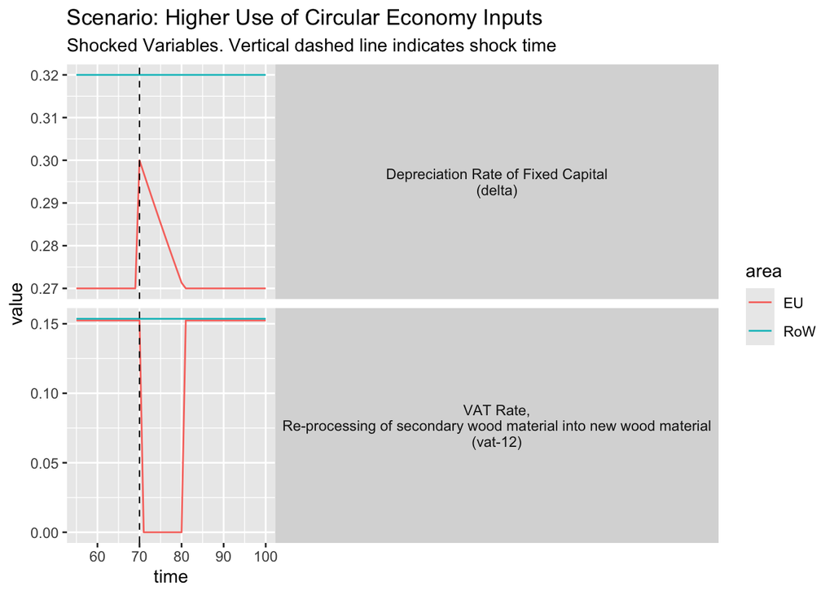

## Visualize Impacts

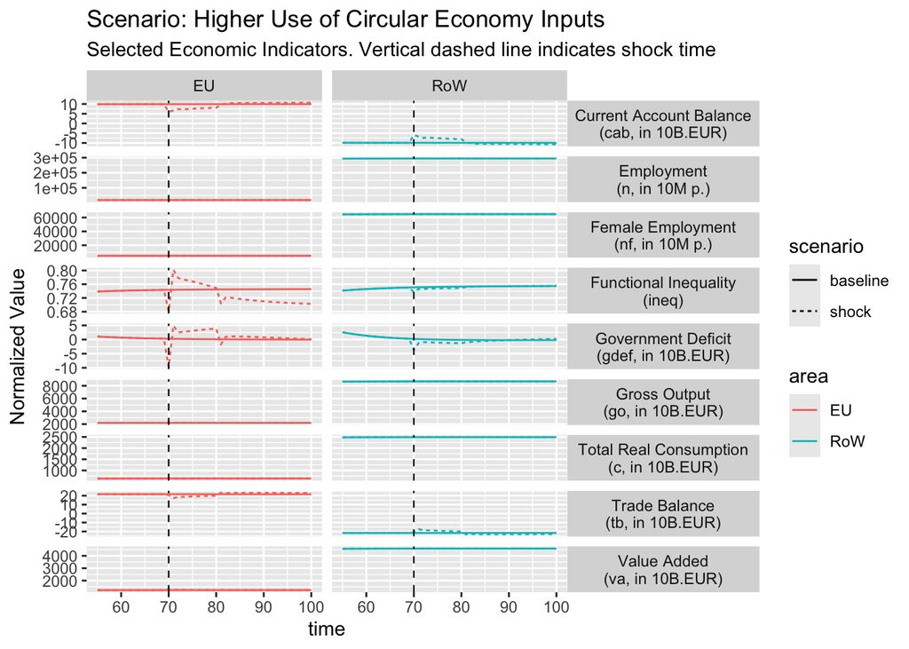

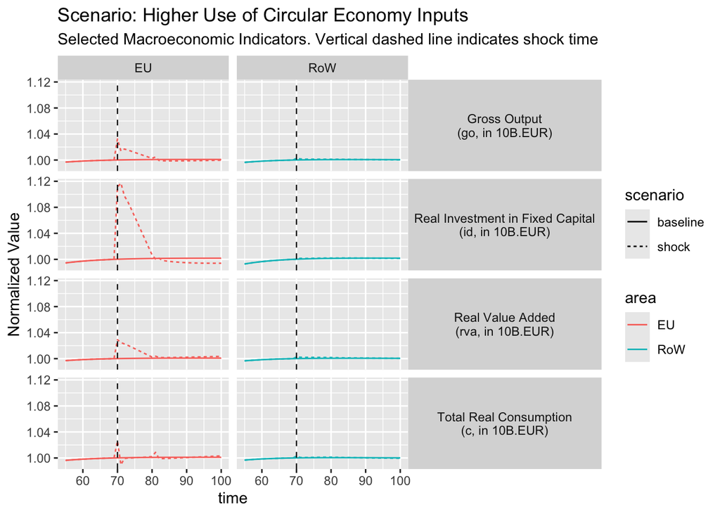

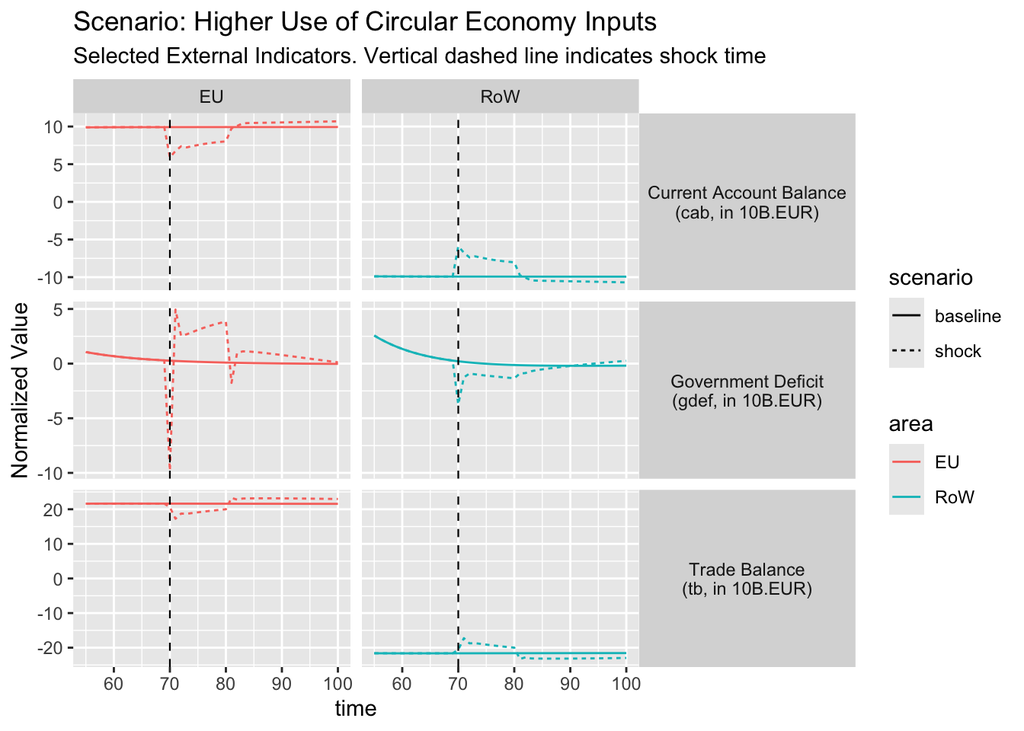

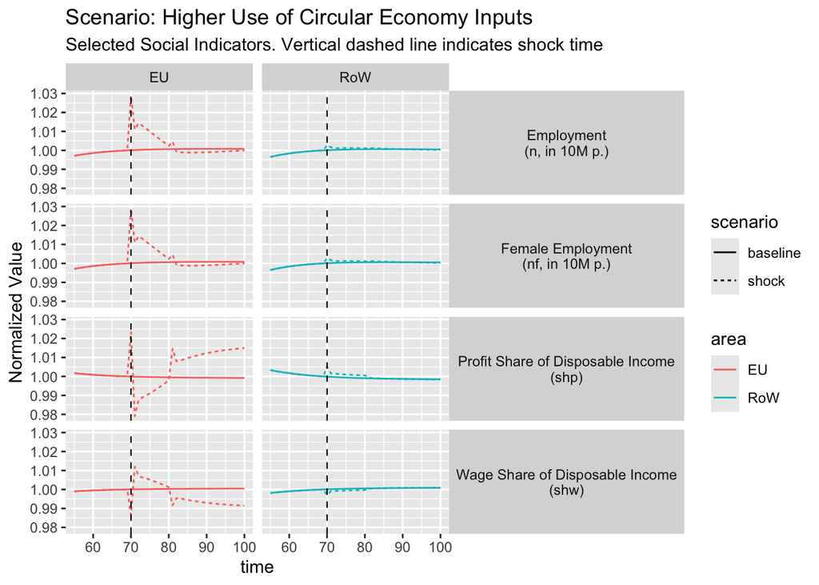

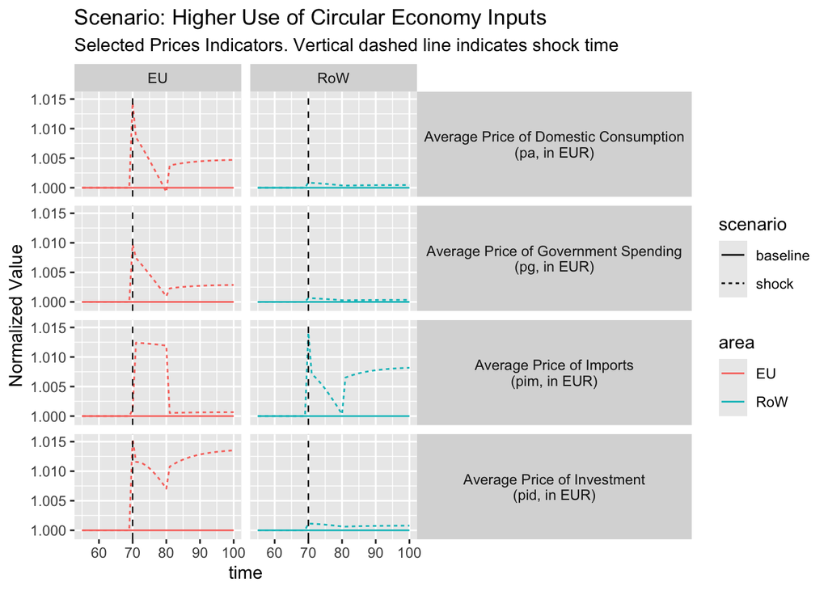

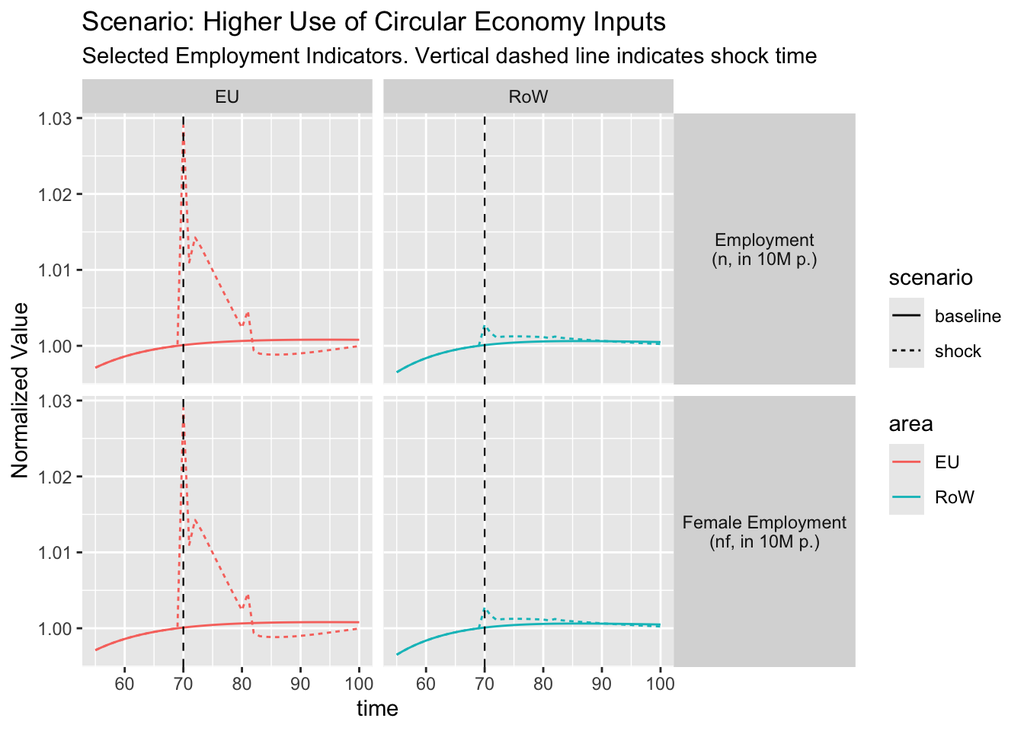

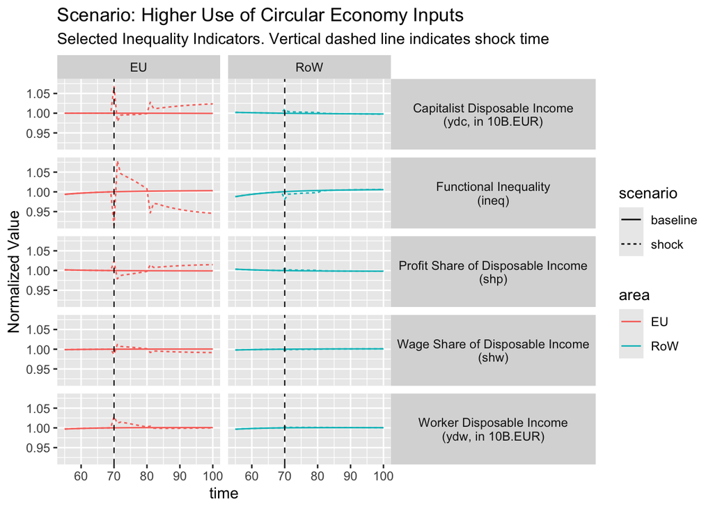

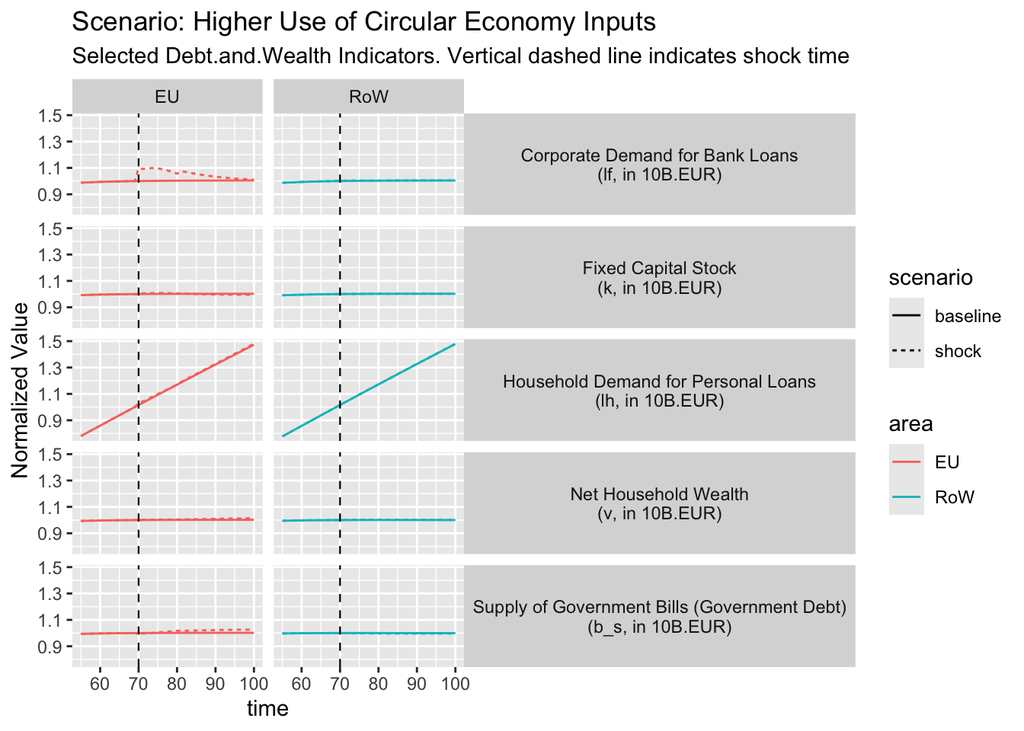

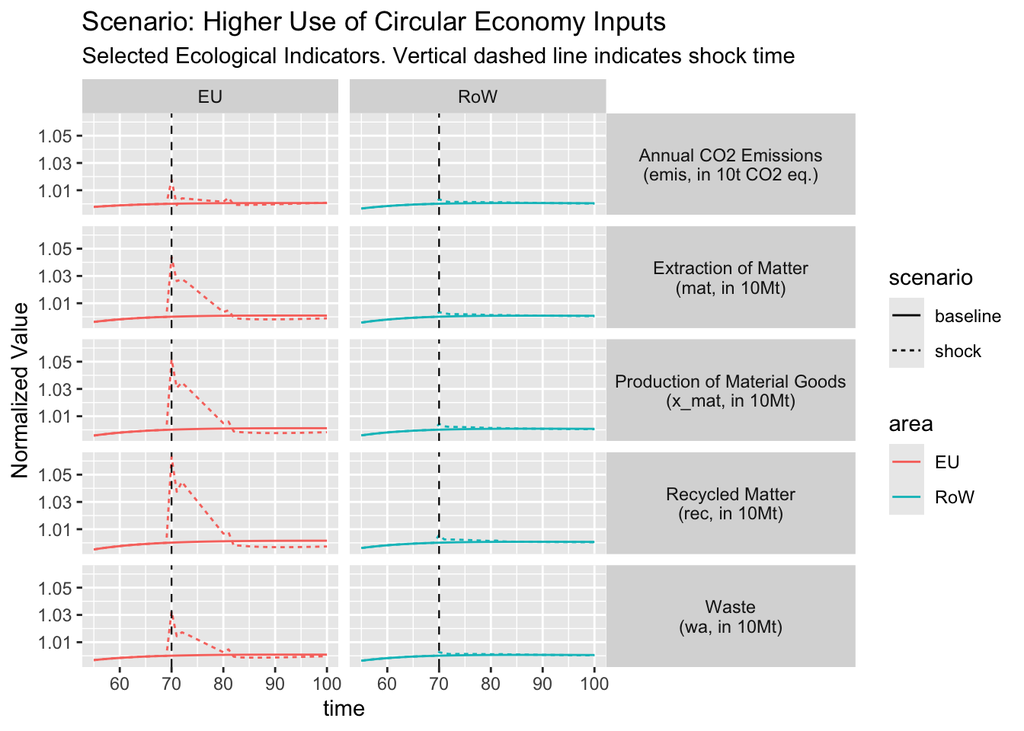

## Summary Table

| Name | Variable | Immediate.Z1 | Short.Term.Z1 | Long.Term.Z1 | Immediate.Z2 | Short.Term.Z2 | Long.Term.Z2 |
| --- | --- | --- | --- | --- | --- | --- | --- |
| Economic | n | 1.08 | 0.63 | -0.18 | 0.15 | 0.07 | 0.00 |
| Economic | c | -1.09 | 0.02 | -0.05 | 0.07 | 0.07 | -0.02 |
| Economic | ineq | 7.83 | 2.23 | -4.70 | -0.68 | -0.56 | 0.03 |
| Economic | va | 1.92 | 0.87 | 0.14 | 0.23 | 0.14 | 0.03 |
| Economic | cab | -31.99 | -21.58 | 6.18 | -31.99 | -21.58 | 6.18 |
| Economic | nf | 1.08 | 0.63 | -0.18 | 0.15 | 0.07 | 0.00 |
| Economic | gdef | 1919.39 | 2494.16 | 5285.69 | -906.17 | 1630.81 | 9.09 |
| Economic | tb | -20.22 | -9.76 | 7.27 | -20.22 | -9.76 | 7.27 |
| Economic | go | 1.37 | 0.74 | -0.21 | 0.16 | 0.08 | 0.01 |
| Macroeconomic | c | -1.09 | 0.02 | -0.05 | 0.07 | 0.07 | -0.02 |
| Macroeconomic | rva | 2.46 | 0.96 | 0.14 | 0.20 | 0.14 | 0.03 |
| Macroeconomic | go | 1.37 | 0.74 | -0.21 | 0.16 | 0.08 | 0.01 |
| Macroeconomic | id | 11.68 | 4.09 | -0.68 | 0.11 | 0.06 | 0.01 |
| External | cab | -31.99 | -21.58 | 6.18 | -31.99 | -21.58 | 6.18 |
| External | gdef | 1919.39 | 2494.16 | 5285.69 | -906.17 | 1630.81 | 9.09 |
| External | tb | -20.22 | -9.76 | 7.27 | -20.22 | -9.76 | 7.27 |
| Social | n | 1.08 | 0.63 | -0.18 | 0.15 | 0.07 | 0.00 |
| Social | nf | 1.08 | 0.63 | -0.18 | 0.15 | 0.07 | 0.00 |
| Social | shp | -2.08 | -0.60 | 1.29 | 0.18 | 0.15 | -0.01 |
| Social | shw | 1.19 | 0.35 | -0.74 | -0.11 | -0.09 | 0.00 |
| Prices | pa | 0.85 | 0.25 | 0.45 | 0.08 | 0.06 | 0.04 |
| Prices | pid | 1.16 | 0.93 | 1.28 | 0.11 | 0.08 | 0.07 |
| Prices | pg | 0.74 | 0.32 | 0.27 | 0.06 | 0.04 | 0.03 |
| Prices | pim | 1.24 | 1.21 | 0.06 | 0.71 | 0.30 | 0.78 |
| Employment | n | 1.08 | 0.63 | -0.18 | 0.15 | 0.07 | 0.00 |
| Employment | nf | 1.08 | 0.63 | -0.18 | 0.15 | 0.07 | 0.00 |
| Inequality | ydw | 1.17 | 0.65 | -0.18 | 0.14 | 0.07 | 0.00 |
| Inequality | ydc | -2.10 | -0.30 | 1.86 | 0.43 | 0.31 | -0.01 |
| Inequality | ineq | 7.83 | 2.23 | -4.70 | -0.68 | -0.56 | 0.03 |
| Inequality | shp | -2.08 | -0.60 | 1.29 | 0.18 | 0.15 | -0.01 |
| Inequality | shw | 1.19 | 0.35 | -0.74 | -0.11 | -0.09 | 0.00 |
| Debt.and.Wealth | lh | 0.95 | 0.32 | 0.45 | 0.09 | 0.07 | 0.06 |
| Debt.and.Wealth | lf | 9.14 | 8.21 | 2.91 | 0.28 | 0.17 | 0.13 |
| Debt.and.Wealth | v | 0.14 | 0.25 | 0.74 | 0.08 | 0.17 | 0.08 |
| Debt.and.Wealth | k | 0.46 | 0.64 | -0.54 | 0.04 | 0.06 | 0.02 |
| Debt.and.Wealth | b_s | -0.39 | 0.84 | 2.10 | -0.11 | -0.23 | -0.37 |
| Ecological | x_mat | 3.06 | 1.53 | -0.35 | 0.24 | 0.11 | 0.00 |
| Ecological | mat | 2.60 | 1.21 | -0.28 | 0.24 | 0.10 | 0.00 |
| Ecological | rec | 3.71 | 2.00 | -0.46 | 0.23 | 0.13 | -0.01 |
| Ecological | emis | -0.11 | 0.20 | -0.09 | 0.18 | 0.08 | 0.01 |
| Ecological | wa | 1.42 | 0.76 | -0.21 | 0.17 | 0.08 | 0.01 |

# Appendix: Table of Industries

| number | industry |
| --- | --- |
| 1 | Agriculture |
| 2 | Animal Farming |
| 3 | Forestry, logging and related service activities (02) |
| 4 | Fishing, operating of fish hatcheries and fish farms; service activities incidental to fishing (05) |
| 5 | Extraction of Fossil-Fuels |
| 6 | Mining & Quarrying of raw materials |
| 7 | Processing of meat |
| 8 | Processing of other food&beverage |
| 9 | Manufacture of tobacco products (16) |
| 10 | Manufacture of textiles |
| 11 | Manufacture of wood and of products of wood and cork, except furniture; manufacture of articles of straw and plaiting materials (20) |
| 12 | Re-processing of secondary wood material into new wood material |
| 13 | Pulp |
| 14 | Re-processing of secondary paper into new pulp |
| 15 | Paper |
| 16 | Processing of Fossil Fuels |
| 17 | Plastics, basic |
| 18 | Re-processing of secondary plastic into new plastic |
| 19 | Manufacture of Chemicals |
| 20 | Manufacture of rubber and plastic products (25) |
| 21 | Manufacture of glass and glass products |
| 22 | Re-processing of secondary glass into new glass |
| 23 | Manufacture of other non-metallic mineral products |
| 24 | Manufacture of cement, lime and plaster |
| 25 | Re-processing of ash into clinker |
| 26 | Manufacture of Metals |
| 27 | Re-processing of Metals |
| 28 | Manufacture of durable goods |
| 29 | Manufacture of furniture; manufacturing n.e.c. (36) |
| 30 | Recycling |
| 31 | Production of electricity by fossil fuels |
| 32 | Production of electricity by renewable energy |
| 33 | Transmission & Distribution |
| 34 | Manufacture of gas; distribution of gaseous fuels through mains |
| 35 | Water |
| 36 | Construction (45) |
| 37 | Re-processing of secondary construction material into aggregates |
| 38 | Sale, maintenance, repair of motor vehicles, motor vehicles parts, motorcycles, motor cycles parts and accessoiries |
| 39 | Retail sale of automotive fuel |
| 40 | Retail & Wholesale trade |
| 41 | Leisure Services |
| 42 | Transport |
| 43 | KIBS |
| 44 | Real estate activities (70) |
| 45 | Renting of machinery and equipment without operator and of personal and household goods (71) |
| 46 | Research and development (73) |
| 47 | Public administration and defence; compulsory social security (75) |
| 48 | Education (80) |
| 49 | Health and social work (85) |
| 50 | Incineration of Waste |
| 51 | Biogas & Composting |
| 52 | Waste water |
| 53 | Landfill of Waste |
| 54 | Other Services |